# Homopolymer Report

Gael Millot

### Results

Randomisation of each sequence was performed 10,000 times without any constrain. Then means were computed for each homopolymer length category.

#### Dot plot

Each dot is a value obtained for one sequence.

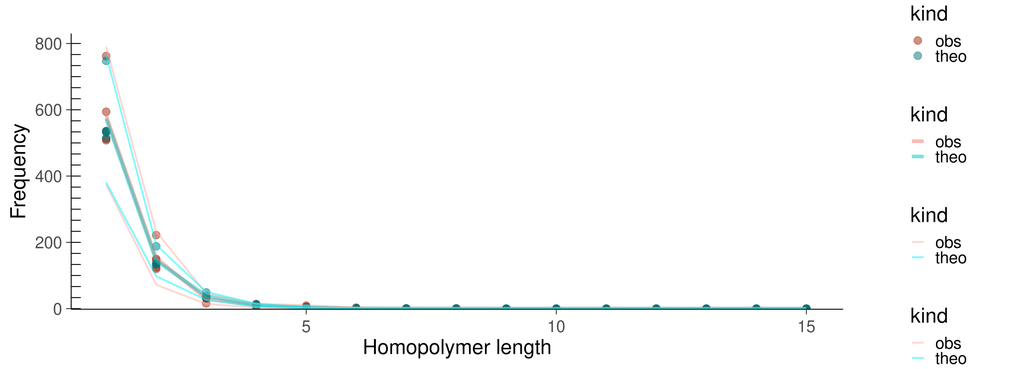

Figure 1: Frequencies of homopolymer lengths.

| length | kind | mean | sd | CI95.inf | CI95.sup |
| --- | --- | --- | --- | --- | --- |
| 1 | obs | 582.4 | 106.107492666635 | 374.429314373395 | 790.370685626605 |
| 2 | obs | 152.4 | 41.0706708004629 | 71.9014852310926 | 232.898514768907 |
| 3 | obs | 29.8 | 7.91833315793166 | 14.2800670104539 | 45.3199329895461 |
| 4 | obs | 9.2 | 2.94957624075052 | 3.41883056812897 | 14.981169431871 |
| 5 | obs | 4.8 | 2.77488738510232 | -0.638779274800551 | 10.2387792748005 |
| 6 | obs | 0.8 | 1.30384048104053 | -1.75552734283944 | 3.35552734283944 |
| 7 | obs | 0.2 | 0.447213595499958 | -0.676538647179918 | 1.07653864717992 |
| 8 | obs | 0.2 | 0.447213595499958 | -0.676538647179918 | 1.07653864717992 |
| 9 | obs | 0 | 0 | 0 | 0 |
| 10 | obs | 0 | 0 | 0 | 0 |
| 11 | obs | 0 | 0 | 0 | 0 |
| 12 | obs | 0 | 0 | 0 | 0 |
| 13 | obs | 0 | 0 | 0 | 0 |
| 14 | obs | 0 | 0 | 0 | 0 |
| 15 | obs | 0 | 0 | 0 | 0 |
| 1 | theo | 572.72306 | 98.1451019533731 | 380.358660171389 | 765.087459828611 |
| 2 | theo | 145.03508 | 24.0293951562872 | 97.937465493677 | 192.132694506323 |
| 3 | theo | 38.47668 | 6.18207129949178 | 26.3598202529961 | 50.5935397470039 |
| 4 | theo | 10.68918 | 2.01578976011885 | 6.73823207016706 | 14.6401279298329 |
| 5 | theo | 3.08418 | 0.777099830781091 | 1.56106433166906 | 4.60729566833094 |
| 6 | theo | 0.92538 | 0.328304533931531 | 0.281903113494198 | 1.5688568865058 |
| 7 | theo | 0.2861 | 0.139351569779461 | 0.0129709232322563 | 0.559229076767744 |
| 8 | theo | 0.08998 | 0.0547338286619893 | -0.017298304177499 | 0.197258304177499 |
| 9 | theo | 0.02978 | 0.0198488538711937 | -0.0091237535875396 | 0.0686837535875396 |
| 10 | theo | 0.00968 | 0.00805679837156175 | -0.00611132480826102 | 0.025471324808261 |
| 11 | theo | 0.00308 | 0.00319327418177644 | -0.00317881739628183 | 0.00933881739628182 |
| 12 | theo | 0.001 | 0.000930053761886914 | -0.000822905373298351 | 0.00282290537329835 |
| 13 | theo | 5e-04 | 0.0006557438524302 | -0.000785257950763192 | 0.00178525795076319 |
| 14 | theo | 0.00012 | 0.000216794833886788 | -0.000304917874418105 | 0.000544917874418105 |
| 15 | theo | 6e-05 | 8.94427190999916e-05 | -0.000115307729435984 | 0.000235307729435984 |

#### Chisquare test

$statistic X-squared 9.576892

$parameter df 14

$p.value [1] 0.7924174

$estimate prop 1 prop 2 prop 3 prop 4 prop 5 prop 6 prop 7 prop 8 0.5041887 0.5123807 0.4364594 0.4625631 0.6088141 0.4636660 0.4114380 0.6897027 prop 9 prop 10 prop 11 prop 12 prop 13 prop 14 prop 15 0.0000000 0.0000000 0.0000000 0.0000000 0.0000000 0.0000000 0.0000000

$null.value NULL

$conf.int NULL

$alternative [1] “two.sided”

$method [1] “15-sample test for equality of proportions without continuity correction”

$data.name [1] “chi2.table”

#### Figure associated to the Chisquare test

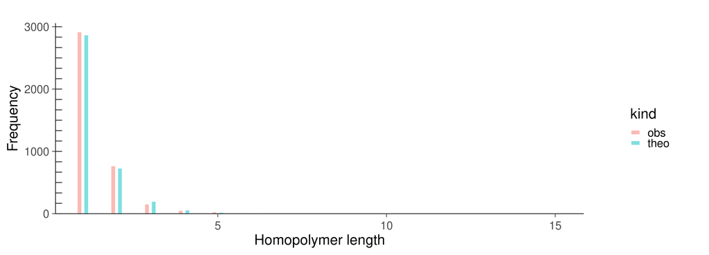

Figure 2: Frequencies of homopolymer lengths.

| length | freq | kind |
| --- | --- | --- |
| 0.9 | 2912 | obs |
| 1.9 | 762 | obs |
| 2.9 | 149 | obs |
| 3.9 | 46 | obs |
| 4.9 | 24 | obs |
| 5.9 | 4 | obs |
| 6.9 | 1 | obs |
| 7.9 | 1 | obs |
| 8.9 | 0 | obs |
| 9.9 | 0 | obs |
| 10.9 | 0 | obs |
| 11.9 | 0 | obs |
| 12.9 | 0 | obs |
| 13.9 | 0 | obs |
| 14.9 | 0 | obs |
| 1.1 | 2863.6153 | theo |
| 2.1 | 725.1754 | theo |
| 3.1 | 192.3834 | theo |
| 4.1 | 53.4459 | theo |
| 5.1 | 15.4209 | theo |
| 6.1 | 4.6269 | theo |
| 7.1 | 1.4305 | theo |
| 8.1 | 0.4499 | theo |
| 9.1 | 0.1489 | theo |
| 10.1 | 0.0484 | theo |
| 11.1 | 0.0154 | theo |
| 12.1 | 0.005 | theo |
| 13.1 | 0.0025 | theo |
| 14.1 | 6e-04 | theo |
| 15.1 | 3e-04 | theo |

### Backup

See the reports folder for all the details of the analysis, including the parameters used in the .config file

Full .nextflow.log is in: /mnt/c/Users/Gael/Documents/Git_projects/homopolymer  
The one in the reports folder is not complete (miss the end)

### Workflow Version

#### General

| Variable | Value |
| --- | --- |
| Project (empty means no .git folder where the main.nf file is present) | origin git@gitlab.pasteur.fr:gmillot/homopolymer.git (fetch) |
| Git info (empty means no .git folder where the main.nf file is present) | v2.0-1-g7b8c93ae6a-dirty |
| Cmd line | nextflow run main.nf -resume |
| execution mode | local |
| Manifest’s pipeline version | null |
| result path | /mnt/c/Users/Gael/Documents/Git_projects/homopolymer/results/20220120_test_1647644596 |
| nextflow version | 21.04.2 |

#### Implicit variables

| Name | Description | Value |
| --- | --- | --- |
| launchDir | Directory where the workflow is run | /mnt/c/Users/Gael/Documents/Git_projects/homopolymer |
| nprojectDir | Directory where the main.nf script is located | /mnt/c/Users/Gael/Documents/Git_projects/homopolymer |
| workDir | Directory where tasks temporary files are created | /mnt/c/Users/Gael/Documents/Git_projects/homopolymer/work |

#### User variables

| Name | Description | Value |
| --- | --- | --- |
| out_path | output folder path | /mnt/c/Users/Gael/Documents/Git_projects/homopolymer/results/20220120_test_1647644596 |
| in_path | input folder path | /mnt/c/Users/gael/Documents/Git_projects/homopolymer/dataset |

#### Workflow diagram

See the nf_dag.png file